# IDBac Instructions for Metcalf Lab

Chase Clark

September 30, 2018

# Excel

## Document sample positions on MALDI plate

[figure not shown]

If you don’t have access to Microsoft Excel, you can use any other spreadsheet software such as: Apache OpenOffice™ “Calc”, which can be found at www.openoffice.org. When saving the file, ensure you save it as type “Microsoft Excel 97/2000/XP (.xls or .xlsx)”.

## Naming the excel file

- The excel file will be named as the date the plate was created and the last five-digits of the MALDI-target-plate serial number:
  - *dd_mm_yyyy_sssss*
  - Use format above, which stands for: (day_month_year_LastFiveOfSerialNumber)

# Preparing the MALDI plate

## Cleaning the MALDI plate

### Murphy Lab

The MALDI plate should be properly cleaned before use. In order to clean the MALDI plate, use the steps below: method adapted from [Freiwald & Sauer](http://www.nature.com/nprot/journal/v4/n5/full/nprot.2009.37.html?foxtrotcallback=true)

1. Remove target plate from holder and rinse with acetone.
2. To remove trace protein/lipids, use non-abrasive liquid soap.
3. Rinse with distilled water ~2 min to completely remove soap.
4. Sonicate in HPLC grade water (Ultrasonic bath) for ~5 min.
5. Rinse with HPLC grade water.
6. Rinse with HPLC grade methanol.

## Metcalf Lab

1. Remove target plate from holder and rinse with HPLC grade methanol.
2. Air-dry, prevent touching or contaminating the top surface of the plate (the side with writing and MALDI-spot circles)

### MALDI Matrix Preparation

1. Prepare 10 mg/mL MALDI-grade [alpha-cyano-4-hydroxycinnamic acid](http://www.sigmaaldrich.com/catalog/search?term=28166-41-8&interface=CAS%20No.&N=0&mode=partialmax&lang=en&region=US&focus=product) (CHCA) in MS-grade solvents:
   - 50% Acetonitrile (ACN)
   - 47.5% Water (H<sub>2</sub>O)
   - 2.5% Trifluoroacetic Acid (TFA)
     - e.g. 400 µL of solution = 200 µL ACN + 190 µL H<sub>2</sub>O + 10 µL TFA + 4 mg CHCA
- You will be using 1 µL per MALDI spot.
- Use matrix solution within 1 week and store unused solid and prepared CHCA matrix between 2-8 °C, in the dark.

### Applying Samples to the MALDI Plate

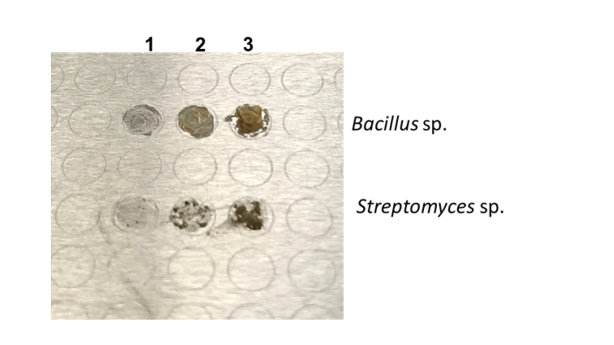

1. Apply bacteria directly without any prior chemical treatment. Smear a single bacterial colony in a thin layer directly onto the MALDI target plate using a sterile toothpick.

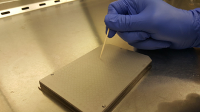

2. Leave the PepMix and BTS spots empty.

3. Add 1 µL of 70% formic acid to each bacterial spot, let air dry.

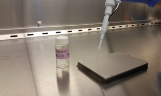

4. Add 1 µL of MALDI matrix to each bacterial spot, let air dry.

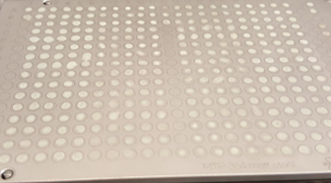

### Shipping MALDI Plates to Metcalf Lab

##### Cleaning MALDI Target Plates

The MALDI plate should be properly cleaned before shipping. In order to clean the MALDI plate, use the steps below: method adapted from [Freiwald & Sauer](http://www.nature.com/nprot/journal/v4/n5/full/nprot.2009.37.html?foxtrotcallback=true)

1. Remove target plate from holder and rinse with acetone.
2. To remove trace protein/lipids, use non-abrasive liquid soap.
3. Rinse with distilled water ~2 min to completely remove soap.
4. Sonicate in HPLC grade water (Ultrasonic bath) for ~5 min.
5. Rinse with HPLC grade water.
6. Rinse with HPLC grade methanol.

### Data Storage

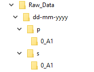